# Profiling Aircraft On Time Preformance for climate-friendly planning.

## Introduction

Air travel is vital to the world economy and in recent years the impact of aviation related activities on climate change has gained prominence. Organizations are pushing for more regulatory controls on such activities to curb the effect of climate change and global warming. This project aims to gain insights to short term strategies that can be implemented to aid solving this challenge, by profiling delays associated with air travel with the aim of shaping the conversation among airlines and regulatory bodies to aid climate friendly planning around minimizing delays.

The dataset contains scheduled and actual departure and arrival times for 2005 and 2008, reported by certified U.S. air carriers that account for at least one percent of domestic scheduled passenger revenues. The data is collected by the Office of Airline Information, Bureau of Transportation Statistics (BTS). Reporting carriers are required to (or voluntarily) report on-time data for flights they operate: on-time arrival and departure data for non-stop domestic flights by month and year, by carrier and by origin and destination airport. Includes scheduled and actual departure and arrival times, canceled and diverted flights, taxi-out and taxi-in times, causes of delay and cancellation, air time, and non-stop distance.

The airlines report the causes of delay in broad categories: Air Carrier, National Aviation System, Weather, Late-Arriving Aircraft and Security. The cancellation codes are the same - A (Carrier), B (weather), C (NAS) and D(security).

i. Air Carrier: The cause of the cancellation or delay was due to circumstances within the airline's control (e.g. maintenance or crew problems, aircraft cleaning, baggage loading, fueling, etc.).

ii. Extreme Weather: Significant meteorological conditions (actual or forecasted) that, in the judgment of the carrier, delays or prevents the operation of a flight such as tornado, blizzard or hurricane.

iii. National Aviation System (NAS): Delays and cancellations attributable to the national aviation system that refer to a broad set of conditions, such as non-extreme weather conditions, airport operations, heavy traffic volume, and air traffic control.

iv. Late-arriving aircraft: A previous flight with same aircraft arrived late, causing the present flight to depart late.

v. Security: Delays or cancellations caused by evacuation of a terminal or concourse, re-boarding of aircraft because of security breach, inoperative screening equipment and/or long lines in excess of 29 minutes at screening areas.

## Preliminary Wrangling

Preliminary wrangling involves importing libraries, files, making copies and data wrangling such as dropping duplicates, filling null values and converting data to appropriate types. A timedelta is applied to the Day of Week column to represent weekday numbers with weekday names.

```python
import numpy as np
import pandas as pd
import matplotlib.pyplot as plt
import seaborn as sb

%matplotlib inline
```

```python
air_05 = pd.read_csv('2005.zip')

air_08 = pd.read_csv('2008.zip')
```

```python
df08 = air_08.copy()

df05 = air_05.copy()
```

```python
df05.drop_duplicates(inplace=True)

df08.drop_duplicates(inplace=True)
```

```python
day_name = ('Monday', 'Tuesday', 'Wednesday', 'Thursday', 'Friday', 'Saturday', 'Sunday')
from datetime import date, timedelta
df05['weekday_name'] = df05['DayOfWeek'].apply(lambda w:(date(2021, 2, 1) + timedelta(days = w)).strftime('%A'))
df08['weekday_name'] = df08['DayOfWeek'].apply(lambda w:(date(2021, 2, 1) + timedelta(days = w)).strftime('%A'))
```

```python
df05.columns = [str(col) + '05' for col in df05.columns]

df08.columns = [str(col) + '08' for col in df08.columns]
```

```python
df05.fillna(0, inplace = True)
df08.fillna(0, inplace = True)
```

```python
cols_times05 = ['DepTime05', 'ArrTime05', "ActualElapsedTime05", "CRSElapsedTime05", 'CarrierDelay05', 'WeatherDelay05', 'NASDelay05', 'SecurityDelay05', 'LateAircraftDelay05', "ArrDelay05", "DepDelay05", "TaxiIn05", 'TaxiOut05', 'AirTime05', 'DayofMonth05']
cols_times08 = ['DepTime08', 'ArrTime08', "ActualElapsedTime08", "CRSElapsedTime08", 'CarrierDelay08', 'WeatherDelay08', 'NASDelay08', 'SecurityDelay08', 'LateAircraftDelay08', "ArrDelay08", "DepDelay08", "TaxiIn08", 'TaxiOut08', 'AirTime08', 'DayofMonth08']

df05[cols_times05] = df05[cols_times05].astype('int64')
df08[cols_times08] = df08[cols_times08].astype('int64')
```

```python
print(df08.shape)
print(df08.dtypes)
print(df08.describe())
```

```
(1048571, 30)
Year08                  int64
Month08                 int64
DayofMonth08            int64
DayOfWeek08             int64
DepTime08               int64
CRSDepTime08            int64
ArrTime08               int64
CRSArrTime08            int64
UniqueCarrier08        object
FlightNum08             int64
TailNum08              object
ActualElapsedTime08     int64
CRSElapsedTime08        int64
AirTime08               int64
ArrDelay08              int64
DepDelay08              int64
Origin08               object
Dest08                 object
Distance08              int64
TaxiIn08                int64
TaxiOut08               int64
Cancelled08             int64
CancellationCode08     object
Diverted08              int64
CarrierDelay08          int64
WeatherDelay08          int64
NASDelay08              int64
SecurityDelay08         int64
LateAircraftDelay08     int64
weekday_name08         object
dtype: object
          Year08       Month08  DayofMonth08   DayOfWeek08     DepTime08  \
count  1048571.0  1.048571e+06  1.048571e+06  1.048571e+06  1.048571e+06
mean      2008.0  1.422295e+00  1.572407e+01  3.895175e+00  1.299948e+03
std          0.0  4.939252e-01  8.728465e+00  1.938097e+00  5.258794e+02
min       2008.0  1.000000e+00  1.000000e+00  1.000000e+00  0.000000e+00
25%       2008.0  1.000000e+00  8.000000e+00  2.000000e+00  9.110000e+02
50%       2008.0  1.000000e+00  1.600000e+01  4.000000e+00  1.318000e+03
75%       2008.0  2.000000e+00  2.300000e+01  5.000000e+00  1.725000e+03
```

[output cut: 28 more lines]

```
50%    1.400000e+01  0.000000e+00  0.000000e+00    0.000000e+00
75%    1.900000e+01  0.000000e+00  0.000000e+00    0.000000e+00
max    3.830000e+02  1.000000e+00  1.000000e+00    1.455000e+03

       WeatherDelay08    NASDelay08  SecurityDelay08  LateAircraftDelay08
count    1.048571e+06  1.048571e+06     1.048571e+06         1.048571e+06
mean     8.385698e-01  4.090377e+00     2.162562e-02         5.660848e+00
std      1.043243e+01  1.727879e+01     8.780303e-01         2.234880e+01
min      0.000000e+00  0.000000e+00     0.000000e+00         0.000000e+00
25%      0.000000e+00  0.000000e+00     0.000000e+00         0.000000e+00
50%      0.000000e+00  0.000000e+00     0.000000e+00         0.000000e+00
75%      0.000000e+00  0.000000e+00     0.000000e+00         0.000000e+00
max      1.049000e+03  1.357000e+03     1.490000e+02         1.143000e+03

[8 rows x 24 columns]
```

### What is/are the main feature(s) of interest in your dataset?

The features that represent the causes and durations for why an aircraft was not operated as scheduled (delay). The arrival and departure delay features together with the cause of the delay including late aircraft arrival, carrier delay, weather, security.

### What features in the dataset do you think will help support your investigation into your feature(s) of interest?

The relationship between the delay cause and duration will be analyzed to discover the relative magnitude of its effect from an associated airline, airport and aircraft, as these are the systems which can cause or suffer a delay.

## Univariate Exploration

I started by creating dataframes to filter bad data, by selecting rows of data that have a positive value for actual elapsed time, up to a 12 hour flight time, to understand the question of how aircrafts travel. Histograms are used to show distribution.

```python
actual_05 = df05[(df05['ActualElapsedTime05'] > 1) & (df05['ActualElapsedTime05'] < 720)]
actual_08 = df08[(df08['ActualElapsedTime08'] > 1) & (df08['ActualElapsedTime08'] < 720)]
```

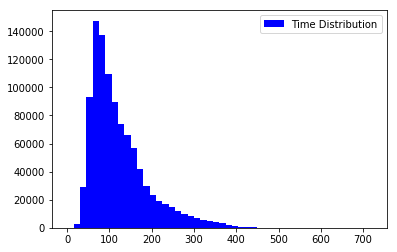

```python
bins05 = np.arange(0, actual_05['ActualElapsedTime05'].max()+15, 15)
plt.hist(actual_05['ActualElapsedTime05'], bins = bins05, facecolor = 'b', alpha =1, label = 'Time Distribution');
plt.legend();
```

What is the time interval for most flights? The visual is plotted on a log scale, with smaller bins of time interval for a clearer picture. Data for 2005 and 2008 is examined.

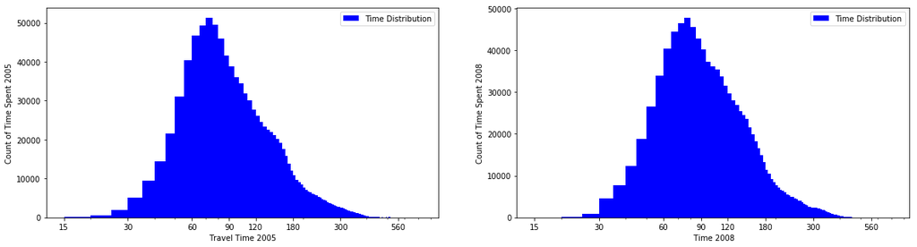

```python
plt.figure(figsize = [20, 5])

plt.subplot(1, 2, 1)

bins05 = np.arange(15, actual_05['ActualElapsedTime05'].max()+5, 5)
plt.hist(actual_05['ActualElapsedTime05'], bins = bins05, facecolor = 'b', alpha =1, label = 'Time Distribution')
plt.xscale('log')
ticks = [15, 30, 60, 90, 120, 180, 300, 560]
labels = ['{}'.format(v) for v in ticks]
plt.legend()
plt.xticks(ticks, labels)
plt.xlabel('Travel Time 2005')
plt.ylabel('Count of Time Spent 2005')

plt.subplot(1, 2, 2)
bins08 = np.arange(15, actual_08['ActualElapsedTime08'].max()+5, 5)
plt.hist(actual_08['ActualElapsedTime08'], bins = bins08, facecolor = 'b', alpha =1, label = 'Time Distribution')
plt.xscale('log')
plt.legend()
plt.xticks(ticks, labels)
plt.xlabel(' Time 2008')
plt.ylabel('Count of Time Spent 2008');
```

What portion of this distribution is impacted by delays?

I examined the departure and arrival features to get a glimpse of how long the delays last. A flight is considered delayed when it goes beyond its scheduled time by 15 mins.

```python
delay_05 = df05[(df05['ArrDelay05'] > 5) & (df05['ArrDelay05'] < 360)]
delay_08 = df08[(df08['ArrDelay08'] > 5) & (df08['ArrDelay08'] < 360)]
```

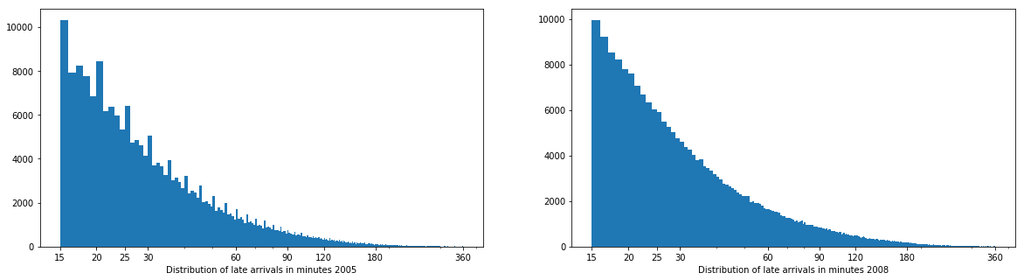

```python
plt.figure(figsize = [20, 5])
base_color = sb.color_palette()[0]

plt.subplot(1, 2, 1)
bins05 = np.arange(15, delay_05['ArrDelay05'].max()+1, 1)

plt.hist(data = delay_05, x = 'ArrDelay05', bins = bins05)
plt.xscale('log')
ticks = [15, 20, 25, 30, 60, 90, 120, 180, 360]
labels = ['{}'.format(v) for v in ticks]
plt.xticks(ticks, labels)
plt.xlabel('Distribution of late arrivals in minutes 2005')

plt.subplot(1, 2, 2)
bins08 = np.arange(15, delay_08['ArrDelay08'].max()+1, 1)
plt.hist(data = delay_08, x = 'ArrDelay08', bins = bins08);
plt.xscale('log')
plt.xticks(ticks, labels)
plt.xlabel('Distribution of late arrivals in minutes 2008');
```

How airlines reported data may have been modified between 2005 and 2008. There are bin peaks every 5 mins interval more pronounced in the 2005 data, possibly due to rounding off delay times.

```python
depdelay_05 = df05[(df05['DepDelay05'] > 5) & (df05['DepDelay05'] < 360)]
depdelay_08 = df08[(df08['DepDelay08'] > 5) & (df08['DepDelay08'] < 360)]
```

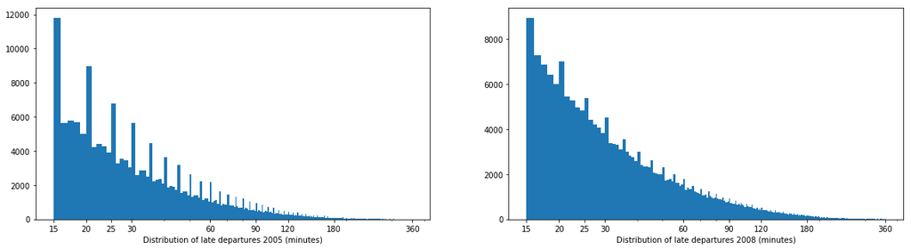

```python
plt.figure(figsize = [20, 5])
base_color = sb.color_palette()[0]

plt.subplot(1, 2, 1)
bins05 = np.arange(15, depdelay_05['DepDelay05'].max()+1, 1)
plt.hist(data = depdelay_05, x = 'DepDelay05', bins = bins05);
plt.xscale('log')
ticks = [15,20, 25, 30, 60, 90, 120, 180, 360]
labels = ['{}'.format(v) for v in ticks]
plt.xticks(ticks, labels);
plt.xlabel('Distribution of late departures 2005 (minutes)')

plt.subplot(1, 2, 2)
bins08 = np.arange(15, depdelay_08['DepDelay08'].max()+1, 1)
plt.hist(data = depdelay_08, x = 'DepDelay08', bins = bins08);
plt.xscale('log')
plt.xticks(ticks, labels)
plt.xlabel('Distribution of late departures 2008 (minutes)');
```

There is a more pronounced reduction in the count of late departures compared to late arrivals.

I took a look at the cause of why flights are not completed as scheduled. Delay and cancellation features are melted into a feature called delay and the corresponding duration of the delay for delays above 15 mins.

```python
df_delay05 = df05.melt(id_vars=['UniqueCarrier05', 'ActualElapsedTime05', 'DepDelay05', 'ArrDelay05', 'Origin05', 'CancellationCode05', 'weekday_name05', 'TailNum05'],
                          value_vars=['CarrierDelay05', 'WeatherDelay05', 'NASDelay05', 'SecurityDelay05', 'LateAircraftDelay05'],
                          var_name='delays05',
                          value_name='duration05')

df_delay08 = df08.melt(id_vars=['UniqueCarrier08', 'ActualElapsedTime08', 'DepDelay08', 'ArrDelay08', 'Origin08', 'CancellationCode08', 'weekday_name08', 'TailNum08'],
                          value_vars=['CarrierDelay08', 'WeatherDelay08', 'NASDelay08', 'SecurityDelay08', 'LateAircraftDelay08'],
                          var_name='delays08',
                          value_name='duration08')
```

```python
df_delay05 = df_delay05.loc[df_delay05['duration05'] >= 15]
df_delay08 = df_delay08.loc[df_delay08['duration08'] >= 15]
```

```python
delay_counts05 = df_delay05['delays05'].value_counts()
delay_order05 = delay_counts05.index
n_delay05 = df_delay05['delays05'].value_counts().sum()
max_delay_count05 = delay_counts05[0]
max_prop05 = max_delay_count05 / n_delay05

delay_counts08 = df_delay08['delays08'].value_counts()
delay_order08 = delay_counts08.index
n_delay08 = df_delay08['delays08'].value_counts().sum()
max_delay_count08 = delay_counts08[0]
max_prop08 = max_delay_count08 / n_delay08

print(max_prop08)
```

```
0.363840499868
```

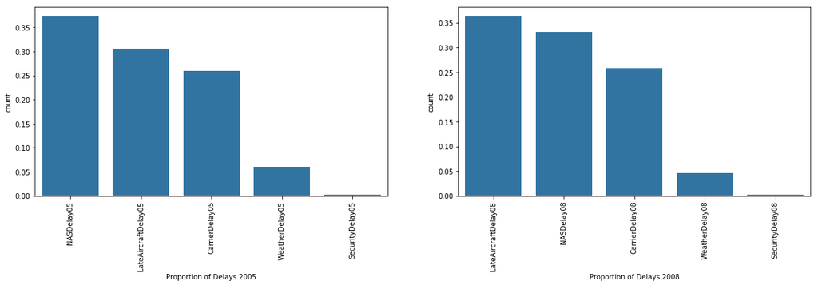

```python
df_delay05 = df_delay05.loc[df_delay05['duration05'] >= 15]
df_delay08 = df_delay08.loc[df_delay08['duration08'] >= 15]

plt.figure(figsize = [20, 5])
base_color = sb.color_palette()[0]

plt.subplot(1, 2, 1)

tick_props05 = np.arange(0, max_prop05, 0.05)
tick_names05 = ['{:0.2f}'.format(v) for v in tick_props05]

sb.countplot(data=df_delay05, x='delays05', color=base_color, order = delay_order05)
plt.xticks(rotation=90)
plt.yticks(tick_props05 * n_delay05, tick_names05)
plt.xlabel('Proportion of Delays 2005');

plt.subplot(1, 2, 2)
tick_props08 = np.arange(0, max_prop08, 0.05)
tick_names08 = ['{:0.2f}'.format(v) for v in tick_props08]

sb.countplot(data=df_delay08, x='delays08', color=base_color, order = delay_order08)
plt.yticks(tick_props08 * n_delay08, tick_names08)
plt.xticks(rotation=90)
plt.xlabel('Proportion of Delays 2008');
```

This is a representation of the count of each cause of delays, not the duration of the delays. It is scaled to the proportion of each delay to the total count. NAS delays represents a broad range of factors. NAS delays show the highest decrease from 2005 to 2008, while late aircraft delays show the highest increase. These delay causes cut across both arrivals and departures.

How can we account and understand these changes at an aircraft, airline and airport level? and in what phase of the flight? Better planning can aid climate friendly strategies; features like these can be monitored to drive behaviours and decisions that can help to measure and reduce the impact of aviation related activities on the climate.

The large range of values for the elapsed flight times and delay times required a log transformation of the x axis for the various dataframes. Melting the delay features enabled observations of the variations in how the various delay causes affect the flight time. The changes in number of delays varied according to the causes.

# Bivariate Exploration

I further examined the relationship between the delay phases and the elapsed time of flight. The scatter plot below shows the delays generally increase with elapsed time of the flight, up to a maximum and gradually decerases as elapsed time increases.

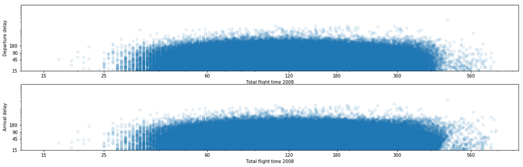

```python
xticks = [15, 25, 60, 120, 180, 300, 560]
ticks = [15, 45, 90, 180]
xlabels = ['{}'.format(v) for v in xticks]
labels = ['{}'.format(v) for v in ticks]
plt.figure(figsize = [20, 6])

plt.subplot(2, 1, 1)
plt.scatter(data = actual_08, x = 'ActualElapsedTime08', y = 'DepDelay08', alpha = 1/10)
plt.xscale('log')
plt.yscale('log')
plt.xticks(xticks, xlabels)
plt.yticks(ticks, labels)
plt.xlabel('Total flight time 2008')
plt.ylabel('Departure delay');

plt.subplot(2, 1, 2)
plt.scatter(data = actual_08, x = 'ActualElapsedTime08', y = 'ArrDelay08', alpha = 1/10)
plt.xscale('log')
plt.yscale('log')
plt.xticks(xticks, xlabels)
plt.yticks(ticks, labels)
plt.xlabel('Total flight time 2008')
plt.ylabel('Arrival delay');
```

The bridge and steep drop in the distribution of elapsed time from the time distribution histogram, may be explained by the abrupt change in point cluster after 300 mins flight time.

The relation between delay phase and delay causes is explored. Both are directly influenced by carrier delays.

What is the magnitude of the delay causes?

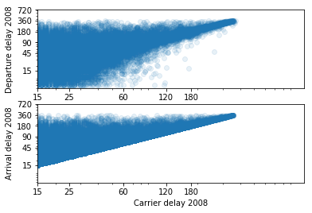

```python
yticks = [15, 45, 90, 180, 360, 720]
xticks = [15, 25, 60, 120, 180]
xlabels = ['{}'.format(v) for v in xticks]
ylabels = ['{}'.format(v) for v in yticks]

plt.subplot(2, 1, 1)
plt.scatter(data = depdelay_08, x = 'CarrierDelay08', y = 'DepDelay08', alpha = 1/10)
plt.xscale('log')
plt.yscale('log')
plt.yticks(yticks, ylabels)
plt.xticks(xticks, xlabels)
plt.xlabel('Carrier delay 2008')
plt.ylabel('Departure delay 2008');

plt.subplot(2, 1, 2)
plt.scatter(data = delay_08, x = 'CarrierDelay08', y = 'ArrDelay08', alpha = 1/10)
plt.xscale('log')
plt.yscale('log')
plt.yticks(yticks, ylabels)
plt.xticks(xticks, xlabels)
plt.xlabel('Carrier delay 2008')
plt.ylabel('Arrival delay 2008');
```

There is a lot more reporting of delays for departures compared to arrivals, for delays times less than 15 mins.

```
actual_08.shape= (1011955, 30)
delay_samp.shape= (500, 30)
```

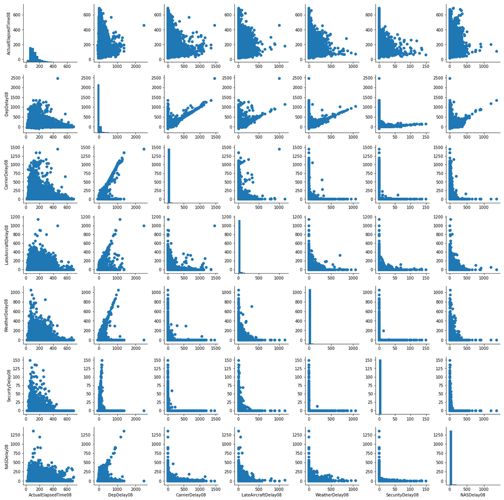

```python
numeric_vars = ['ActualElapsedTime08', 'DepDelay08', 'CarrierDelay08', 'LateAircraftDelay08', 'WeatherDelay08', 'SecurityDelay08', 'NASDelay08']

print("actual_08.shape=",actual_08.shape)
delay_samp = actual_08.sample(n=500, replace = False)
print("delay_samp.shape=",delay_samp.shape)

g = sb.PairGrid(data = actual_08, vars = numeric_vars)
g.map_diag(plt.hist, bins = 20);
g.map_offdiag(plt.scatter);
```

```python
df_delay05.head()
```

[output not shown]

The duartion of each delay cause was plotted on a bar chart, by grouping each delay cause with its corresponding mean duration and plotting the mean values of each delay for 2005 and 2008.

Some values present as negative values; some flights operated earlier than the scheduled.

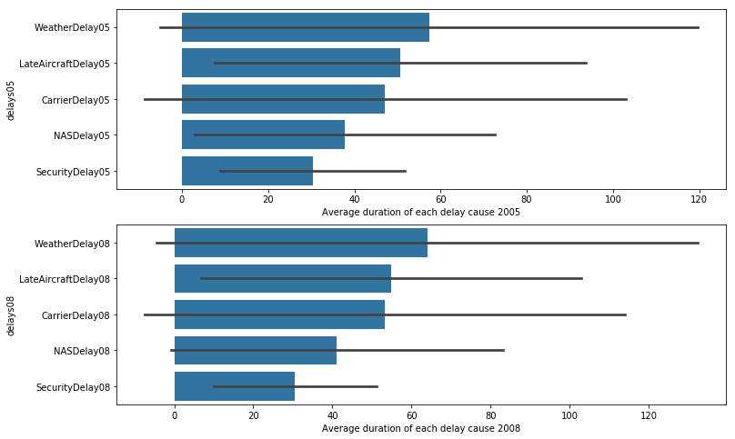

```python
plt.figure(figsize = [12, 8])
plt.subplot(2, 1, 1)

THRESHOLD = 1
delay_frequency = df_delay05['delays05'].value_counts()
idx = np.sum(delay_frequency > THRESHOLD)
most_delays = delay_frequency.index[:idx]
dist_delays = df_delay05.loc[df_delay05['delays05'].isin(most_delays)]
delay_means = dist_delays.groupby('delays05').mean()
dur_order = delay_means.sort_values('duration05', ascending = False).index

base_color = sb.color_palette()[0]
sb.barplot(data = dist_delays, x = 'duration05', y = 'delays05',
           color = base_color, order = dur_order, ci = 'sd')
plt.xlabel('Average duration of each delay cause 2005')

plt.subplot(2, 1, 2)
delay_frequency08 = df_delay08['delays08'].value_counts()
idx08 = np.sum(delay_frequency08 > THRESHOLD)
most_delays08 = delay_frequency08.index[:idx08]
dist_delays08 = df_delay08.loc[df_delay08['delays08'].isin(most_delays08)]
delay_mean08 = dist_delays08.groupby('delays08').mean()
dur_order08 = delay_mean08.sort_values('duration08', ascending = False).index

base_color = sb.color_palette()[0]
sb.barplot(data = dist_delays08, x = 'duration08', y = 'delays08',
           color = base_color, order = dur_order08, ci = 'sd')
plt.xlabel('Average duration of each delay cause 2008');
```

Weather delays had the highest average duration. Carrier delays have a lower average duration but have a wider stretch, with maximum values higher than late aircraft delays. NAS delays which have the highest count of delays, has one of the lower average duration. This is in contrast with the earlier bar chart that shows NAS delay having the highest count of delays but seen here with the fourth highest mean. The breakdown of cancelled flights show improvement in cancellation due weather but not so with carrier and NAS.

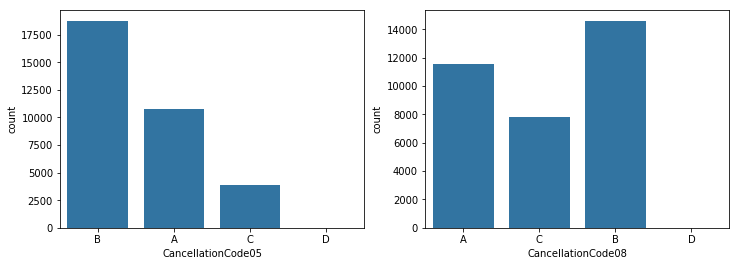

```python
plt.figure(figsize = [12, 4])

plt.subplot(1, 2, 1)
df_cancel05 = df05[df05['CancellationCode05'] != 0]
sb.countplot(data=df_cancel05, x='CancellationCode05', color=base_color)
g.add_legend()

plt.subplot(1, 2, 2)
df_cancel = df08[df08['CancellationCode08'] != 0]
sb.countplot(data=df_cancel, x='CancellationCode08', color=base_color)
g.add_legend();
```

Cancellations are mostly due to weather (B) then carrier (A).

How are these delays spread out among the various airlines?

Due to the large size of data, I used a threshold of an airline having at least 500 events.

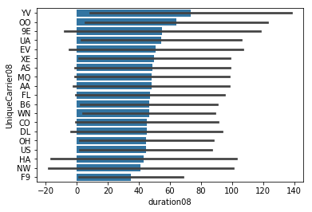

```python
THRESHOLD = 500
carr_frequency = df_delay08['UniqueCarrier08'].value_counts()
idx = np.sum(carr_frequency > THRESHOLD)
most_flyers = carr_frequency.index[:idx]
high_flyers = df_delay08.loc[df_delay08['UniqueCarrier08'].isin(most_flyers)]
fly_means = high_flyers.groupby('UniqueCarrier08').mean()
comb_order = fly_means.sort_values('duration08', ascending = False).index
base_color = sb.color_palette()[0]
sb.barplot(data = high_flyers, x = 'duration08', y = 'UniqueCarrier08',
color = base_color, order = comb_order, ci = 'sd')
```

The figure shows the airlines with the highest average duration of delays; while the figure below shows the statistics of flight times for each airline. Average delay duration varies by airline.

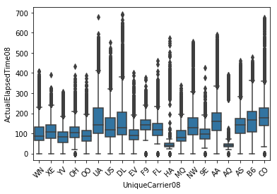

```python
sb.boxplot(data=df08, x='UniqueCarrier08', y='ActualElapsedTime08', color = base_color)
plt.xticks(rotation = 45);
```

Spread of the duration of a typical flight operated by each airline. Some airlines with short average flight times have a high delay duration, and airlines with long flight times have short delay durations.

The figure below shows a distribution of the count of delays above 15 mins. Airlines with higher average delay durations across all delay causes are not necessarily the airlines with the most delays. Aircraft, represented by tail numbers, influences the count of an airline (number of flights). NB: Airline AQ not registered in plot due to low count.

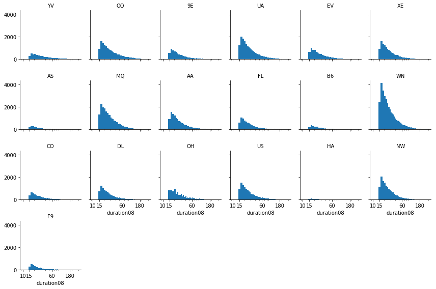

```python
bins = np.arange(10, 300+2, 2)
g = sb.FacetGrid(data = df_delay08, col = 'UniqueCarrier08', col_wrap = 6, size = 2,col_order = comb_order)
g.map(plt.hist, 'duration08', bins = bins)
plt.xscale('log')
ticks = [10, 15, 60, 180]
labels = ['{}'.format(v) for v in ticks]
plt.xticks(ticks, labels)
g.set_titles('{col_name}');
```

```python
print(actual_08['UniqueCarrier08'].value_counts())
#print(depdelay_08['UniqueCarrier08'].value_counts())
```

```
WN    192409
OO     90141
MQ     77945
US     74538
UA     71663
XE     64963
NW     59064
DL     55896
AA     50640
EV     43351
FL     40220
YV     39145
9E     36689
OH     34082
CO     24946
B6     16207
F9     14750
AS     12289
HA      9017
AQ      4000
Name: UniqueCarrier08, dtype: int64
```

Surprisingly, airline WN have a below average duration of delay and a high count of delays (flights). Its median flight time is below 100minutes. OO operatesa similar flight time but with much higher average delay duration.

While the average and count of delays have been obtained further exploration can highlight the weighted impact of a delay on an airline, aircraft or airport.

## Multivariate Exploration

How can the impact of the delays be measured on departures and arrivals? How can a specific airline, aircraft or airport be profiled for improvements in its delay numbers?

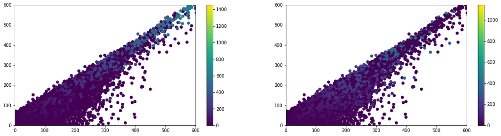

```python
plt.figure(figsize = [12, 5])
plt.subplot(1, 2, 1)
plt.scatter(data = actual_08, x = 'ArrDelay08', y = 'DepDelay08', c = 'CarrierDelay08')
plt.colorbar()
plt.xlim(0,600)
plt.ylim(0,600)

plt.subplot(1, 2, 2)
plt.scatter(data = actual_08, x = 'ArrDelay08', y = 'DepDelay08', c = 'LateAircraftDelay08')
plt.colorbar()
plt.xlim(0,600)
plt.ylim(0,600);
```

There is a concentration of carrier delays at the higher values of departure and arrival delays. This is in contrast with the average and count of delays from the univariate and bivariate exploration.

I introduced each airlines delay cause to have a broader view.

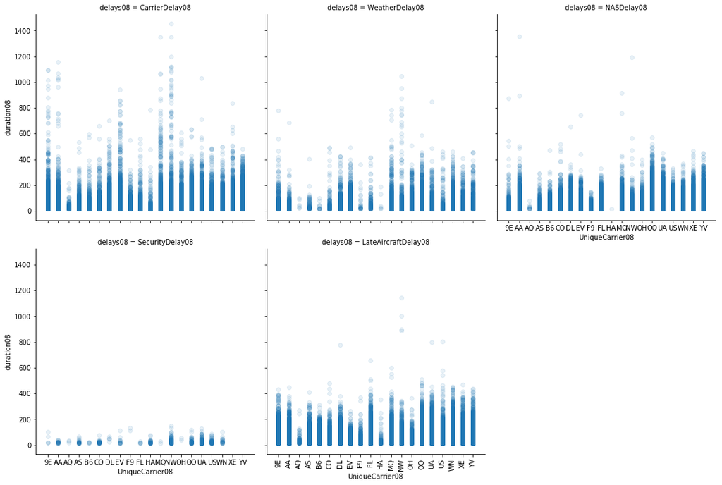

```python
plt.figure(figsize = [15, 8])

g = sb.FacetGrid(data = df_delay08, col = 'delays08', col_wrap = 3, size = 5,
                margin_titles = True)
g.map(plt.scatter, 'UniqueCarrier08', 'duration08', alpha = 1/10)
plt.xticks(rotation=90);
```

Some airlines have some high peak delay numbers, but not as high on the averages; the aggregate of all airlines appear as though carrier delays are the biggest cause of delays. These are individual occurences. The clustered charts below give more detail about each airline. Airline OO is the second most affected by average weather delays but doesnt have the highest peak values for weather delay duration.

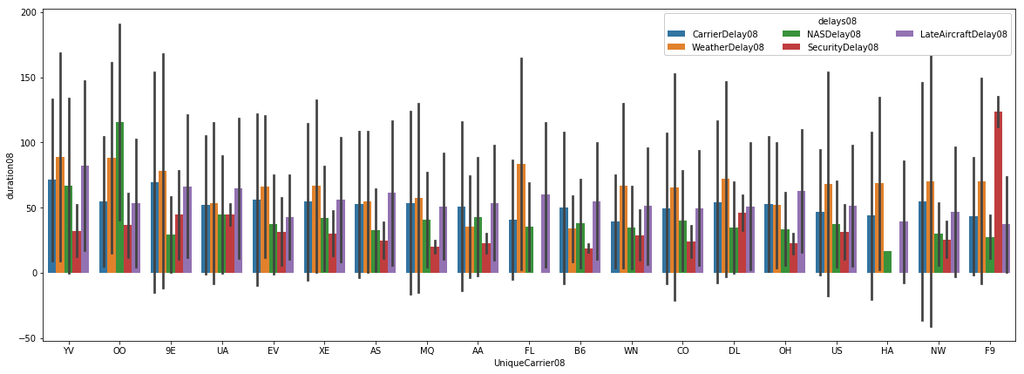

```python
plt.figure(figsize = [20, 7])
fly_mean = high_flyers.groupby('UniqueCarrier08').mean()
carr_order = fly_mean.sort_values('duration08', ascending = False).index
ax = sb.barplot(data = high_flyers, x = 'UniqueCarrier08', y = 'duration08', hue = 'delays08', order = carr_order, ci = 'sd')
ax.legend(loc = 1, ncol = 3, framealpha = 1, title = 'delays08');
```

Airline WN with a high flight count maintains a relatively low average.

```
Text(0.5,0,'Airlines')
```

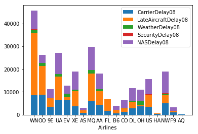

```python
cat1_order = ['WN', 'OO', '9E', 'UA', 'EV', 'XE', 'AS', 'MQ', 'AA', 'FL', 'B6', 'CO', 'DL', 'OH', 'US', 'HA', 'NW', 'F9', 'AQ']
cat2_order = ['CarrierDelay08', 'LateAircraftDelay08', 'WeatherDelay08', 'SecurityDelay08', 'NASDelay08']

baselines = np.zeros(len(cat1_order))
# for each second-variable category:
for i in range(len(cat2_order)):
    # isolate the counts of the first category,
    cat2 = cat2_order[i]
    inner_counts = df_delay08[df_delay08['delays08'] == cat2]['UniqueCarrier08'].value_counts()
    # then plot those counts on top of the accumulated baseline
    plt.bar(x = np.arange(len(cat1_order)), height = inner_counts[cat1_order],
            bottom = baselines)
    baselines += inner_counts[cat1_order]

plt.xticks(np.arange(len(cat1_order)), cat1_order)
plt.legend(cat2_order)
plt.xlabel('Airlines');
```

For perspective, the plot above shows the cumulative effect of the delays on the airlines.

Heatmaps of the average impact of each delay cause on an airline, airport and aircraft, for a varying thresholds of frequency in the dataset. Aircrafts of the same type and similar routes can be investigated to make comparisons. Airlines can understand how various delays causes impact operations and compare in various airports.

```python
THRESHOLD = 200
carr_frequency = df_delay08['UniqueCarrier08'].value_counts()
idx = np.sum(carr_frequency > THRESHOLD)
most_carr = carr_frequency.index[:idx]
Airline_delay = df_delay08.loc[df_delay08['UniqueCarrier08'].isin(most_carr)]
Airline_means = Airline_delay.groupby('UniqueCarrier08').mean()
airline_order = Airline_means.sort_values('duration08', ascending = False).index
```

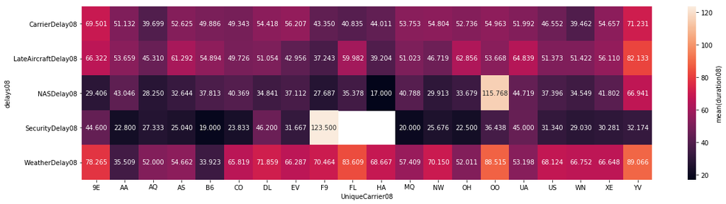

```python
plt.figure(figsize = [20, 5])

cat_means = Airline_delay.groupby(['UniqueCarrier08', 'delays08']).mean()['duration08']
cat_means = cat_means.reset_index(name = 'airline_order')
cat_means = cat_means.pivot(index = 'delays08', columns = 'UniqueCarrier08',
                            values = 'airline_order')
sb.heatmap(cat_means, annot = True, fmt = '.3f',
           cbar_kws = {'label' : 'mean(duration08)'});
```

```python
carr_frequency
```

```
WN    45699
MQ    29732
UA    27091
OO    26250
XE    19033
NW    18855
AA    17963
US    15658
EV    12703
DL    11730
FL    11451
9E    11316
OH    11003
YV    10901
CO     6400
B6     3825
F9     3270
AS     3140
HA      522
AQ      254
Name: UniqueCarrier08, dtype: int64
```

Airlines with average duration of delays due each delay cause. DL has a lower overall average duration than AA, but DL has a lower count of flight in the threshold considered in the heatmap than AA (airlines with over 200 flights with delays of 15mins and above); AA does a better job with delays. Airline YV has some pretty bad numbers and may have burnt some extra gallons of jet fuel in the process. Weather delays will not be as bad, with better planning. The cascading effect a late aircraft delay can cause can also be improved.

The threshold of consideration will affect the apparent average delays.

```python
THRESHOLD = 200
tail_frequency = df_delay08['TailNum08'].value_counts()
idx = np.sum(tail_frequency > THRESHOLD)
most_tails = tail_frequency.index[:idx]
delayAC = df_delay08.loc[df_delay08['TailNum08'].isin(most_tails)]
tail = delayAC.groupby('TailNum08').mean()
tail_order = tail.sort_values('duration08', ascending = False).index
```

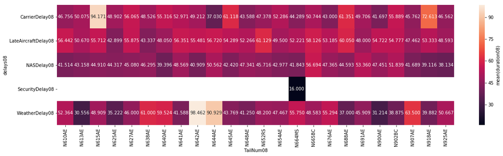

```python
plt.figure(figsize = [20, 5])

cat_means = delayAC.groupby(['TailNum08', 'delays08']).mean()['duration08']
cat_means = cat_means.reset_index(name = 'tail_order')
cat_means = cat_means.pivot(index = 'delays08', columns = 'TailNum08',
                            values = 'tail_order')
sb.heatmap(cat_means, annot = True, fmt = '.3f',
           cbar_kws = {'label' : 'mean(duration08)'});
```

Aircrafts with over 200 events having average delays over 15 mins. Tail numbers that have probably kept airport facilities working longer than scheduled. Frequent flyers are usually not impacted with security delays. Delays can be narrowed to the aircraft and the corresponding airline to tackle delay causes.

```python
THRESHOLD = 3000
airp_frequency = df_delay08['Origin08'].value_counts()
idx = np.sum(airp_frequency > THRESHOLD)
most_airp = airp_frequency.index[:idx]
AP_delay = df_delay08.loc[df_delay08['Origin08'].isin(most_airp)]
AP_means = AP_delay.groupby('Origin08').mean()
ap_order = AP_means.sort_values('duration08', ascending = False).index
```

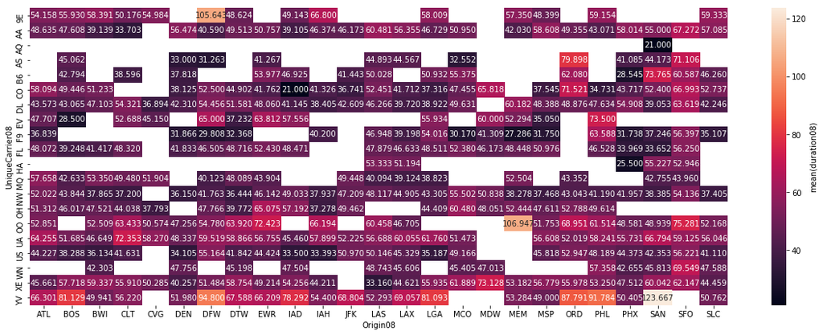

```python
plt.figure(figsize = [20, 7])

cat_means = AP_delay.groupby(['Origin08', 'UniqueCarrier08']).mean()['duration08']
cat_means = cat_means.reset_index(name = 'ap_order')
cat_means = cat_means.pivot(index = 'UniqueCarrier08', columns = 'Origin08',
                            values = 'ap_order')
sb.heatmap(cat_means, annot = True, fmt = '.3f',
           cbar_kws = {'label' : 'mean(duration08)'});
```

Airports of departure that recorded at least 3000 delays from various airlines with above 15 mins durations. Airline OO doesnt perform as well in airports EWR, SFO and MEM. We can investigate further to find out what happened in airport MEM for a root cause of the unusually high NAS delay suffered by the airline.

The heatmap provides a broader view of how each delay cause impacts the various airlines and can be traced to what phase of the flight envelope (arrival or departure) by the airport where the event occurred.

## Conclusions

This visualization profiling of the delay cause, durations and phase of occurrence has generated insights into how airlines are affected by various delays with the corresponding location of occurrence. The effect of average and individual values can be misleading when not put in context of the dataset. Weather delays may appear to be the leading cause of delays when aggregated; It however turns out airlnes are more impacted by other delays cumulatively but when a weather delay occurs, it may last longer.

It can be useful for planning of scheduled flight times, to improve the on time performance of aircraft at various airports and reduce the impact of wasted time and resources which delays cause, as the impact of aviation related activities on the climate can be reduced with short term stategies.

```python
from subprocess import call
call(['python', '-m', 'nbconvert', 'Part_I_exploration_template.ipynb'])
```

```
0
```